# Qploidy

## From Illumina array

In case you have a Illumina array summary file, `Qploidy` expects the following format:

```
[Header]
GSGT Version    2.0.5
Processing Date 4/17/2023 9:31 AM
Content         specieX.bpm
Num SNPs        26251
Total SNPs      26251
Num Samples     100
Total Samples   100

[Data]
SNP Name   Sample ID   GC Score   Theta   X      Y      X Raw   Y Raw   Log R Ratio
mk-1       SAMP-2      0.6814     0.247   0.023  0.009  504     100     0.5211668
mk-10      SAMP-2      0.9204     0.000   0.006  0.000  346     27      -1.021583
mk-100     SAMP-2      0.1695     0.367   0.030  0.020  576     158     1.177404
mk-101     SAMP-2      0.8655     0.222   0.026  0.010  538     102     0.3459635
mk-103     SAMP-2      0.8932     0.000   0.019  0.000  465     18      0.7578704
mk-104     SAMP-2      0.5146     0.175   0.041  0.012  675     114     1.016254
mk-105     SAMP-2      0.8060     0.450   0.018  0.015  458     132     0.4305636
mk-106     SAMP-2      0.0000     0.386   0.002  0.002  315     57      NaN
mk-107     SAMP-2      0.4804     0.495   0.026  0.025  534     189     1.0151
```

Verify if you file look like this one. If confirmed, you can use the `read_illumina_array` function to read the data. If you include more than one file, the function will merge them into a single data frame.

```r
data <- read_illumina_array(
  "data/illumina/Set1.txt", # This is a example code, data not available
  "data/illumina/Set2.txt",
  "data/illumina/Set3.txt"
)
head(input_data)
```

```
MarkerName     SampleName     X     Y     R     ratio
1        CT1         S1-2_1 0.023 0.009 0.032 0.2812500
2       CT10         S1-2_1 0.006 0.000 0.006 0.0000000
3      CT100         S1-2_1 0.030 0.020 0.050 0.4000000
4      CT101         S1-2_1 0.026 0.010 0.036 0.2777778
5      CT103         S1-2_1 0.019 0.000 0.019 0.0000000
6      CT104         S1-2_1 0.041 0.012 0.053 0.2264151
```

# Define Reference Samples - Choose Path (1) or (2)

`Qploidy` applies a standardization method to allele intensities or read counts to enable the comparison of copy numbers across the genome of a sample. To achieve this, it requires a set of reference samples. There are two ways to select these reference samples:

1. **If you have a subset of samples with known ploidy**, `Qploidy` will use this subset as the reference.
2. **If you know the most common ploidy among your samples**, you can initially run `Qploidy` using all samples as the reference. From this first run, you can identify samples with the common ploidy, then select this subset to use as the reference in a second run of `Qploidy`.

Below are the steps to proceed for each case, tagged as (1) and (2):

## (1) Using a Subset with Known Ploidy

For this method, you will need to separate your subset of samples with known ploidy:

In our simulated example, the sample names tell us which ploidy they are. Let’s just create a vector with the tetraploid samples for us to use later:

```r
# All samples
all_samples <- unique(data$SampleName)
all_samples
```

```
##  [1] "Tetraploid1"  "Tetraploid2"  "Tetraploid3"  "Tetraploid4"  "Tetraploid5"
##  [6] "Tetraploid6"  "Tetraploid7"  "Tetraploid8"  "Tetraploid9"  "Tetraploid10"
## [11] "Tetraploid11" "Tetraploid12" "Tetraploid13" "Tetraploid14" "Tetraploid15"
## [16] "Tetraploid16" "Tetraploid17" "Tetraploid18" "Tetraploid19" "Tetraploid20"
## [21] "Tetraploid21" "Tetraploid22" "Tetraploid23" "Tetraploid24" "Tetraploid25"
## [26] "Tetraploid26" "Tetraploid27" "Tetraploid28" "Tetraploid29" "Tetraploid30"
## [31] "Tetraploid31" "Tetraploid32" "Tetraploid33" "Tetraploid34" "Tetraploid35"
## [36] "Diploid1"     "Diploid2"     "Diploid3"     "Diploid4"     "Diploid5"
## [41] "Triploid1"    "Triploid2"    "Triploid3"    "Triploid4"    "Triploid5"
## [46] "Triploid6"    "Triploid7"    "Triploid8"    "Triploid9"    "Triploid10"
```

```r
tetraploid_samples <- all_samples[grep("Tetraploid", all_samples)]
tetraploid_samples
```

```
##  [1] "Tetraploid1"  "Tetraploid2"  "Tetraploid3"  "Tetraploid4"  "Tetraploid5"
##  [6] "Tetraploid6"  "Tetraploid7"  "Tetraploid8"  "Tetraploid9"  "Tetraploid10"
## [11] "Tetraploid11" "Tetraploid12" "Tetraploid13" "Tetraploid14" "Tetraploid15"
## [16] "Tetraploid16" "Tetraploid17" "Tetraploid18" "Tetraploid19" "Tetraploid20"
## [21] "Tetraploid21" "Tetraploid22" "Tetraploid23" "Tetraploid24" "Tetraploid25"
## [26] "Tetraploid26" "Tetraploid27" "Tetraploid28" "Tetraploid29" "Tetraploid30"
## [31] "Tetraploid31" "Tetraploid32" "Tetraploid33" "Tetraploid34" "Tetraploid35"
```

## (2) Using the Most Common Ploidy

For this method, you will use the entire dataset as the reference during the first round of the `Qploidy` run:

```r
data_reference <- data
```

# (1) and (2) Run Dosage Caller

To proceed, you need to determine the dosage for all reference samples. If you haven’t done this yet, you can use any suitable dosage caller.

- For **array data**, we recommend using the [`fitPoly`](https://CRAN.R-project.org/package=fitPoly) package.
- For **sequencing data**, we suggest using the [`updog`](https://github.com/dcgerard/updog) or [`polyRAD`](https://github.com/lvclark/polyRAD) packages.

These packages determine dosages by analyzing the distribution of allele intensities or read counts across all samples for each marker, using an informed ploidy model. You will provide either the **most common ploidy in your population** or the **known ploidy of your selected subset** as the informed ploidy.

- **Path (2):** If you provide the most common ploidy, samples with different ploidy levels may receive incorrect dosages. However, these samples can be filtered out in the next step.

**Warning:**  
Depending on the number of samples and markers, this step may take a significant amount of time to complete. It is highly recommended to run it on a high-performance computing system where you can utilize multiple cores and avoid issues with excessive RAM usage.

### Target sequencing VCF data

- If the VCF file already contains dosage/genotype information called for the subset/most common ploidy:

```r
genos <- qploidy_read_vcf("vcf_example_simulated.vcf", geno = TRUE)
dim(genos)
```

```
## [1] 50000     4
```

```r
genos.pos <- qploidy_read_vcf("vcf_example_simulated.vcf", geno.pos = TRUE)
head(genos.pos)
```

```
##   MarkerName Chromosome Position
## 1   chr1_mk1       chr1   249732
## 2   chr1_mk2       chr1   347883
## 3   chr1_mk3       chr1   709781
## 4   chr1_mk4       chr1   758053
## 5   chr1_mk5       chr1   794442
## 6   chr1_mk6       chr1   823933
```

- If the VCF file lacks marker names in the `ID` column of the fixed portion, the `MarkerName` column will contain `NAs`. To resolve this, you can use the following code to concatenate the chromosome and position as marker names:

```r
genos.pos$MarkerName <- paste0(genos.pos$Chromosome, "_", genos.pos$Position)
head(genos.pos)
```

#### (1) Filter the genos object to keep only the known ploidy samples subset

```r
genos <- genos[which(genos$SampleName %in% tetraploid_samples), ]
```

- If the VCF file doesn’t contain dosage/genotype information (GT format field) called for the subset/most common ploidy:

```r
library(tidyr)

# Prepare inputs for updog
## Approach (1)
# tobe_genotyped <- data[which(data$SampleName %in% tetraploid_samples),]

## Approach (2)
tobe_genotyped <- data

ref <- pivot_wider(tobe_genotyped[, 1:3], names_from = SampleName, values_from = X)
ref <- as.matrix(ref)
rownames_ref <- ref[, 1]
ref <- ref[, -1]
ref <- apply(ref, 2, as.numeric)
rownames(ref) <- rownames_ref

size <- pivot_wider(tobe_genotyped[, c(1, 2, 5)], names_from = SampleName, values_from = R)
size <- as.matrix(size)
rownames_size <- size[, 1]
size <- size[, -1]
size <- apply(size, 2, as.numeric)
rownames(size) <- rownames_size

size[1:10, 1:10]
```

```
##           Tetraploid1 Tetraploid2 Tetraploid3 Tetraploid4 Tetraploid5
## chr1_mk1          215         202         188         212         202
## chr1_mk2          184         194         208         205         213
## chr1_mk3          182         200         193         196         214
## chr1_mk4          189         202         202         203         203
## chr1_mk5          194         209         200         199         207
## chr1_mk6          186         206         178         195         205
## chr1_mk7          216         200         206         191         193
## chr1_mk8          196         215         201         209         199
## chr1_mk9          198         216         211         197         205
## chr1_mk10         204         195         205         187         205
##           Tetraploid6 Tetraploid7 Tetraploid8 Tetraploid9 Tetraploid10
## chr1_mk1          195         195         205         210          196
## chr1_mk2          200         195         209         200          195
## chr1_mk3          205         199         205         194          220
## chr1_mk4          215         204         218         203          188
## chr1_mk5          213         208         191         191          208
## chr1_mk6          203         191         200         197          200
## chr1_mk7          214         198         204         203          198
## chr1_mk8          212         200         195         197          205
## chr1_mk9          204         198         200         189          208
## chr1_mk10         212         200         201         199          200
```

```r
ref[1:10, 1:10]
```

```
##           Tetraploid1 Tetraploid2 Tetraploid3 Tetraploid4 Tetraploid5
## chr1_mk1           62          98          97         156         158
## chr1_mk2           93          92          56         105         158
## chr1_mk3          143         110         146          52          98
## chr1_mk4           43         102         149         158          95
## chr1_mk5          101         107         200         153         151
## chr1_mk6          148         102          40          49          56
## chr1_mk7          112           0         150         141          94
## chr1_mk8           50          56          54         155         101
## chr1_mk9           98         104          58         101         108
## chr1_mk10         145         148         151         145         106
##           Tetraploid6 Tetraploid7 Tetraploid8 Tetraploid9 Tetraploid10
## chr1_mk1          147         149         154          99          145
## chr1_mk2          103          50         104           0           45
## chr1_mk3          150          53         100         105          109
## chr1_mk4           55          50         105         165          144
## chr1_mk5           56         154         154          98          101
## chr1_mk6          150          94           0         147            0
## chr1_mk7           70          99          50          98          154
## chr1_mk8          151         151         140          46          114
## chr1_mk9           54          44         101          86          156
## chr1_mk10          96         200         152         150          200
```

```r
library(updog)
multidog_obj <- multidog(
  refmat = ref,
  sizemat = size,
  model = "norm", # It depends of your population structure
  ploidy = 4, # Most common ploidy in your population
  nc = 6
) # Change the parameters accordingly!!
```

```
##     |                                   *.#,%
##    |||                                 *******/
##  |||||||    (**..#**.                  */   **/
## |||||||||    */****************************/*%
##    |||    &****..,*.************************/
##    |||     (....,,,*,...****%********/(******
##    |||                ,,****%////,,,,./.****/
##    |||                  /**//         .*///....
##    |||                  .*/*/%#         .,/   .,
##    |||               , **/   #%         .*    ..
##    |||                               ,,,*
##
## Working on it...done!
```

```r
genos <- data.frame(
  MarkerName = multidog_obj$inddf$snp,
  SampleName = multidog_obj$inddf$ind,
  geno = multidog_obj$inddf$geno,
  prob = multidog_obj$inddf$maxpostprob
)

head(genos)
```

```
##   MarkerName  SampleName geno      prob
## 1   chr1_mk1 Tetraploid1    1 0.9999976
## 2   chr1_mk1 Tetraploid2    2 0.9999999
## 3   chr1_mk1 Tetraploid3    2 0.9999999
## 4   chr1_mk1 Tetraploid4    3 0.9999997
## 5   chr1_mk1 Tetraploid5    3 1.0000000
## 6   chr1_mk1 Tetraploid6    3 1.0000000
```

Notice that, if you are following approach (2) diploids and triploids samples genotypes will be wrongly called as tetraploids. But, because they are not the most common samples in the dataset, they should not interfere significantly in the dosage call of the tetraploids. You can go back to this step after a first round of ploidy evaluation and call the dosage of the tetraploids only.

### Array data

Here we show an option of genotype calling for array data using fitpoly software:

```r
library(fitPoly)
saveMarkerModels(
  ploidy = 4, # Most common ploidy among Texas Garden Roses collection
  data = data_reference, # output of the previous function
  filePrefix = "fitpoly_output/texas_roses", # Define the path and prefix for the result files
  ncores = 2
) # Change it accordingly to your system!!!!

library(vroom) # Package to speed up reading files
fitpoly_scores <- vroom("fitpoly_output/texas_roses_scores.dat")

genos <- data.frame(
  MarkerName = fitpoly_scores$MarkerName,
  SampleName = fitpoly_scores$SampleName,
  geno = fitpoly_scores$maxgeno,
  prob = fitpoly_scores$maxP
)
head(genos)
```

```
   MarkerName  SampleName geno      prob
1 AX-86752740 1000 Wishes    2 0.7831438
2 AX-86752740  10004-N008    2 0.9892338
3 AX-86752740  10037_N046    2 0.9844171
4 AX-86752740  10038-N001    2 0.9916813
5 AX-86752740  10043_N019    2 0.9871057
6 AX-86752740  10043_N049    2 0.9955792
```

Differently than a VCF file, a `summary` file does not contain the genomic positions of the markers. You will need to provide these information in a separate file as the following example.

```r
# File containing markers genomic positions
genos.pos_file <- read.table("geno.pos_roses_texas.txt", header = T)
head(genos.pos)
```

```
            SNP      probes chr      pos
1 Affx-86843634 AX-86752747   6   255852
2 Affx-86842821 AX-86752763   6 62032267
3 Affx-86839613 AX-86752769   5  9169310
4 Affx-86838724 AX-86752790   1 44259488
5 Affx-86840823 AX-86752809   7 12991931
6 Affx-86842443 AX-86752817   2 53861719
```

```r
# Edit for Qploidy input format
genos.pos <- data.frame(
  MarkerName = genos.pos_file$probes,
  Chromosome = genos.pos_file$chr,
  Position = genos.pos_file$pos
)
head(genos.pos)
```

```
   MarkerName Chromosome Position
1 AX-86752747          6   255852
2 AX-86752763          6 62032267
3 AX-86752769          5  9169310
4 AX-86752790          1 44259488
5 AX-86752809          7 12991931
6 AX-86752817          2 53861719
```

# (1) and (2) Standardization

[output not shown]

[output not shown]

```r
simu_data_standardized <- standardize(
  data = data,
  genos = genos,
  geno.pos = genos.pos,
  ploidy.standardization = 4,
  threshold.n.clusters = 5,
  n.cores = 1,
  out_filename = "my_standardized_data.tsv.gz",
  verbose = TRUE
)

simu_data_standardized
```

How it look like for our real roses dataset:

```
This is on object of class 'ploidy_standardization'
--------------------------------------------------------------------
Parameters

1 standardization type:                                      intensities
2 Ploidy:                                                    4
3 Minimum number of heterozygous classes (clusters) present: 5
4 Maximum number of missing genotype by marker:              0.1
5 Minimum genotype probability:                              0.8
--------------------------------------------------------------------
Filters

1 Number of markers at raw data:                                            137786 (100%)
2 Percentage of filtered genotypes by probability threshold:                -      (16.79 %)
3 Number of markers filtered by missing data:                               5659   (4.11 %)
4 Number of markers filtered for not having the minimum number of clusters: 101853 (73.92 %)
5 Number of markers filtered for not having genomic information:            252    (0.18 %)
6 Number of markers with estimated BAF:                                     28100  (20.39 %)
```

See the details of the parameters with `?standardize`.

The `print` function of the resulting object provides information about marker filtering during the process. One critical filtering step involves the number of dosage clusters represented for each marker. If your samples are highly inbred at certain loci, you might not have individuals representing all possible dosages for those marker locations.

For example, when using tetraploids as the reference, some markers may have individuals with dosages of only 0, 1, 3, and 4 (missing dosage 2). Without representatives for the missing dosage, `Qploidy` standardization cannot be performed.

- If `threshold.n.clusters` is set to `ploidy + 1`, markers with missing dosages will be discarded.
- If `threshold.n.clusters` is smaller than `ploidy + 1`, the missing dosage cluster centers will be imputed for standardization purposes.

## Recover the `ploidy_standardization` Object from a Saved File

To revisit this step later without re-running the upstream functions, you can load the previously generated file using the `read_qploidy_standardization` function:

```r
simu_data_standardized <- read_qploidy_standardization("my_standardized_data.tsv.gz")
```

# (1) and (2) Plot results

`Qploidy` provides several options for visualization of the results. Check the complete description with `?plot_qploidy_standaridization`. Bellow you can see examples:

```r
# Select a sample to be evaluated
samples <- unique(simu_data_standardized$data$SampleName)
head(samples)
```

```
## [1] "Tetraploid1" "Tetraploid2" "Tetraploid3" "Tetraploid4" "Tetraploid5"
## [6] "Tetraploid6"
```

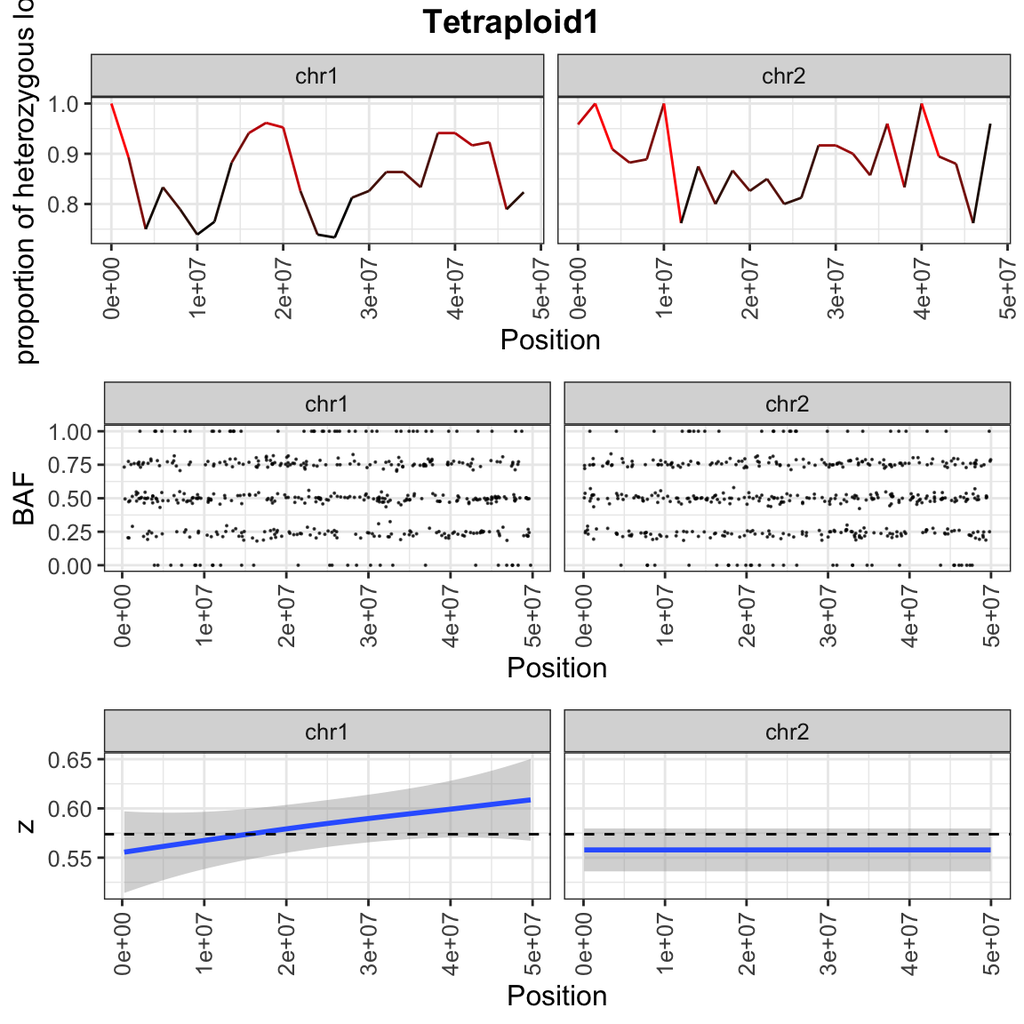

```r
sample <- "Tetraploid1"

# Proportion of heterozygous loci, BAF (Qploidy standardized ratio), and zscore by genomic positions
p <- plot_qploidy_standardization(
  x = simu_data_standardized,
  sample = sample,
  type = c("het", "BAF", "zscore"),
  dot.size = 0.05,
  chr = 1:2
)
p
```

See how it look like for our real roses dataset:

[figure not shown]

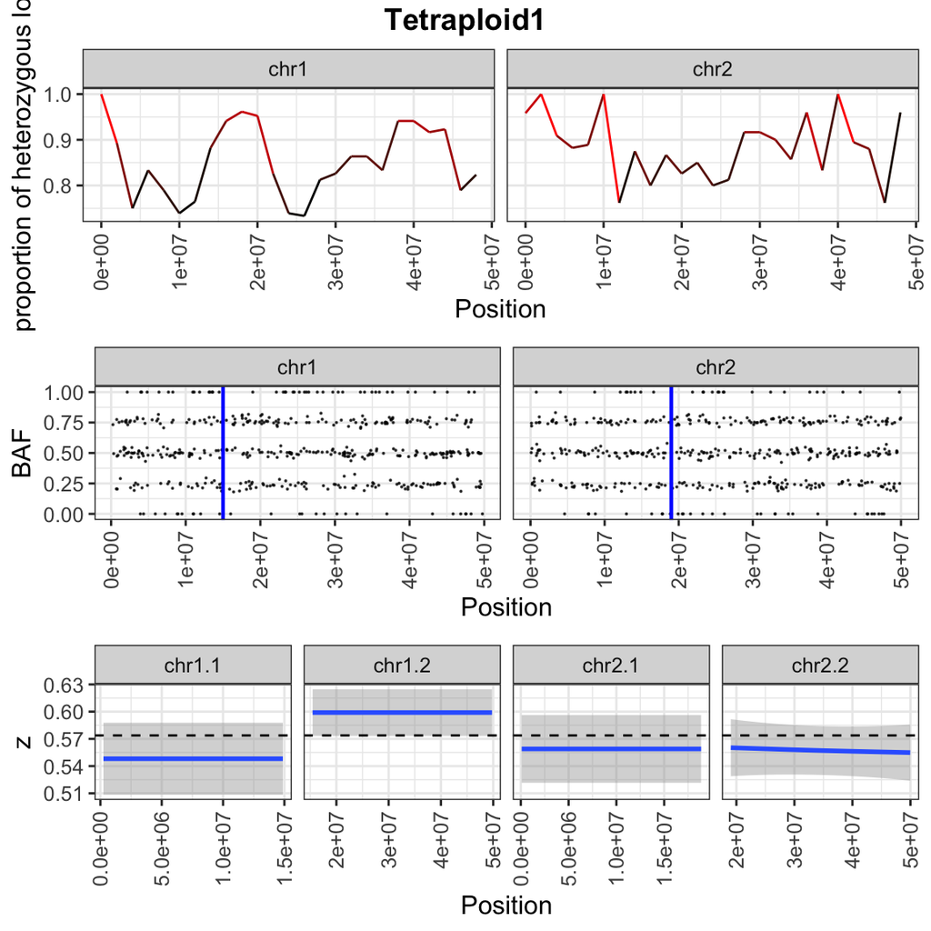

```r
# Heterozygous frequency, BAF (Qploidy standardized ratio), and zscore by genomic positions
# centromere positions added
p <- plot_qploidy_standardization(
  x = simu_data_standardized,
  sample = sample,
  type = c("het", "BAF", "zscore"),
  dot.size = 0.05,
  chr = 1:2,
  add_centromeres = TRUE,
  centromeres = c("chr1" = 15000000, "chr2" = 19000000)
)
p
```

See how it look like for our real roses dataset:

[figure not shown]

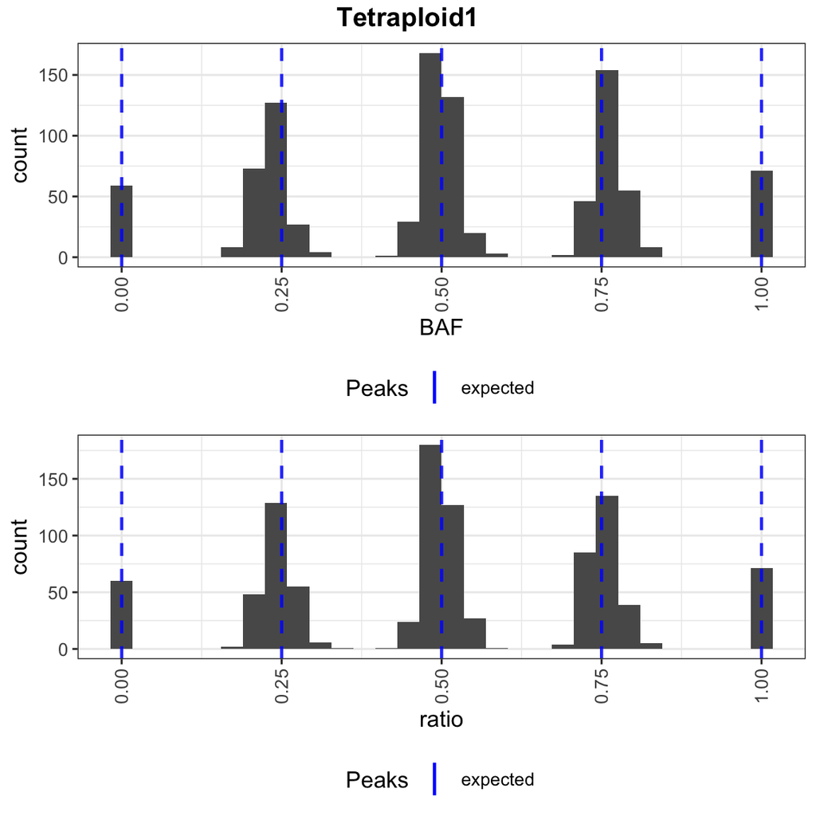

```r
# Raw allele intensity or read count ratio and BAF (Qploidy standardized ratio) histograms
# combining all markers in the sample (sample level resolution)
p <- plot_qploidy_standardization(
  x = simu_data_standardized,
  sample = sample,
  type = c("Ratio_hist_overall", "BAF_hist_overall"),
  chr = 1:2,
  ploidy = 4,
  add_expected_peaks = TRUE
)
p
```

Notice that, because it is a simulated data, the ratio and the BAF don’t differ much. See how it look like for our real roses dataset:

[figure not shown]

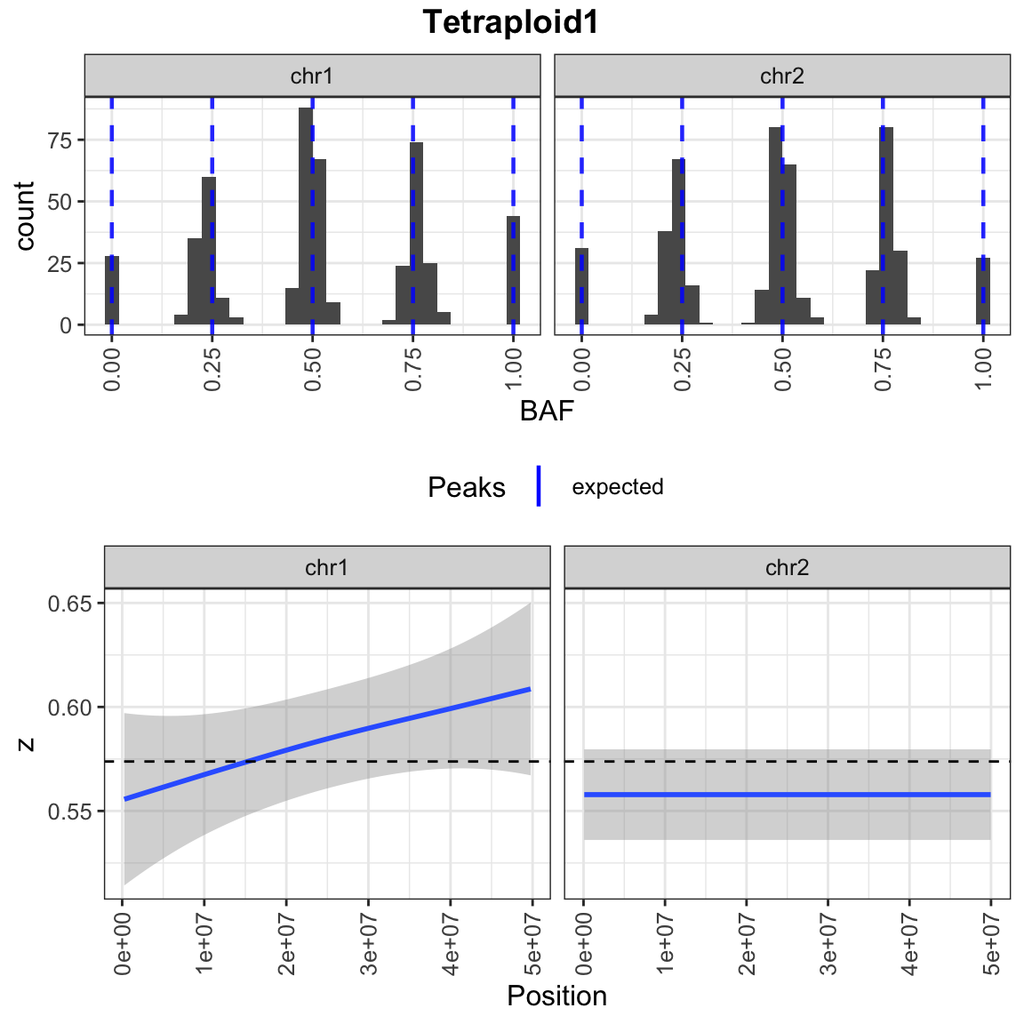

```r
# BAF histograms (chromosome level resolution) and Z score
p <- plot_qploidy_standardization(
  x = simu_data_standardized,
  sample = sample,
  type = c("BAF_hist", "zscore"),
  chr = 1:2,
  add_expected_peaks = TRUE,
  ploidy = c(4, 4)
)
p
```

See how it look like for our real roses dataset:

[figure not shown]

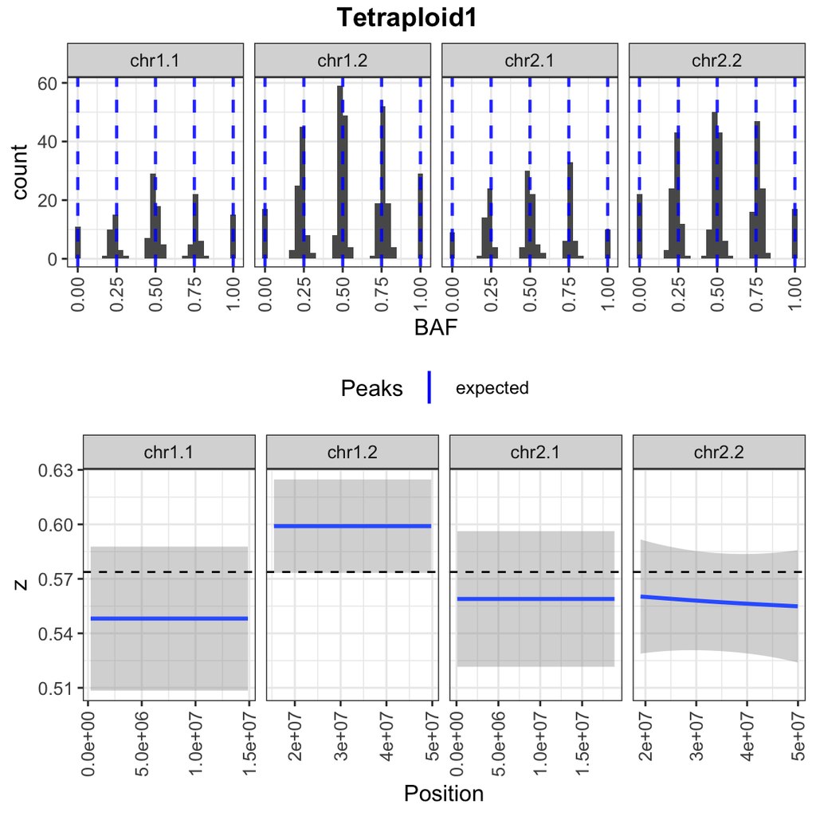

```r
# BAF histograms combining all markers in the sample (chromosome-arm level resolution) and Z score
p <- plot_qploidy_standardization(
  x = simu_data_standardized,
  sample = sample,
  type = c("BAF_hist", "zscore"),
  chr = 1:2,
  ploidy = c(4, 4, 4, 4), # Provide ploidy for each arm
  add_expected_peaks = TRUE,
  add_centromeres = TRUE,
  centromeres = c("chr1" = 15000000, "chr2" = 19000000)
)
p
```

See how it look like for our real roses dataset:

[figure not shown]

It is important to note that the quality of results can vary across samples, as observed in different plots. Key aspects to assess include:  
- How sharp the peaks are in the histogram plots.  
- How well the dots cluster in the BAF vs. genomic position plots.  
- Whether the patterns match the decay or increase of the Z-score (Z).

In our publication, we categorize sample quality into different **resolutions** based on the ability to estimate copy numbers, ranked from highest to lowest resolution:  
1. **Chromosome-arm resolution**: When the copy number of all chromosome arms can be estimated.  
2. **Chromosome resolution**: When at least one chromosome arm’s copy number cannot be estimated.  
3. **Sample resolution**: When the copy number of at least one entire chromosome cannot be estimated.  
4. **None**: When the histogram peaks, considering all markers, do not fit any of the expected ploidy levels tested.

For more details and examples, please refer to the publication.

# (1) and (2) Ploidy Estimation for All Samples

**Warning**: This method may not be fully accurate in certain situations. While it offers a helpful initial guide, **visual inspection** of the plots described in the previous section is essential to assess the resolution and confirm the ploidy.

```r
# If sample level resolution
estimated_ploidies_sample <- area_estimate_ploidy(
  qploidy_standardization = simu_data_standardized, # standardization result object
  samples = "all", # Samples or "all" to estimate all samples
  level = "sample", # Resolution level
  ploidies = c(2, 3, 4, 5)
) # Ploidies to be tested
estimated_ploidies_sample
```

```
## Object of class qploidy_area_ploidy_estimation
## 1 Number of samples:                     50
## 2 Chromosomes:                           chr1,chr2
## 3 Tested ploidies:                       1,2,3,4,5
## 4 Number of euploid samples:             50
## 5 Number of potential aneuploid samples: 0
## 6 Number of highly inbred samples:       0
```

See how it look like for our real roses dataset:

```
Object of class qploidy_area_ploidy_estimation
1 Number of samples:                     524
2 Chromosomes:                           1,3,5,2,6,7,4,0
3 Tested ploidies:                       1,2,3,4,5
4 Number of euploid samples:             459
5 Number of potential aneuploid samples: 0
6 Number of highly inbred samples:       65
```

Highly inbred samples cannot be evaluated for copy number using this method. As a result, `Qploidy` returns a missing value (`NA`) for these cases.

```r
head(estimated_ploidies_sample$ploidy)
```

```
##             [,1]
## Tetraploid1    4
## Tetraploid2    4
## Tetraploid3    4
## Tetraploid4    4
## Tetraploid5    4
## Tetraploid6    4
```

See how it look like for our real roses dataset:

```
               [,1]
Lemon_Fiz         4
High_Voltage      4
Lemon_Fiz.1       4
High_Voltage.1    4
Brite_Eyes        4
Morden_Blush.1    4
```

```r
# If chromosome resolution
estimated_ploidies_chromosome <- area_estimate_ploidy(
  qploidy_standardization = simu_data_standardized,
  samples = "all",
  level = "chromosome",
  ploidies = c(2, 3, 4, 5)
)
estimated_ploidies_chromosome
```

```
## Object of class qploidy_area_ploidy_estimation
## 1 Number of samples:                     50
## 2 Chromosomes:                           chr1,chr2
## 3 Tested ploidies:                       1,2,3,4,5
## 4 Number of euploid samples:             50
## 5 Number of potential aneuploid samples: 0
## 6 Number of highly inbred samples:       0
```

See how it look like for our real roses dataset:

```
Object of class qploidy_area_ploidy_estimation
1 Number of samples:                     524
2 Chromosomes:                           0,1,2,3,4,5,6,7
3 Tested ploidies:                       1,2,3,4,5
4 Number of euploid samples:             375
5 Number of potential aneuploid samples: 92
6 Number of highly inbred samples:       57
```

```r
head(estimated_ploidies_chromosome$ploidy)
```

```
##             chr1 chr2
## Tetraploid1    4    4
## Tetraploid2    4    4
## Tetraploid3    4    4
## Tetraploid4    4    4
## Tetraploid5    4    4
## Tetraploid6    4    4
```

See how it look like for our real roses dataset:

```
               0 1 2 3 4 5 6 7
Lemon_Fiz      4 4 4 4 4 4 4 4
High_Voltage   4 4 4 4 4 4 4 4
Lemon_Fiz.1    4 4 4 4 4 4 4 4
High_Voltage.1 4 4 4 4 4 4 4 4
Brite_Eyes     4 4 4 4 4 4 4 4
Morden_Blush.1 4 4 4 4 4 4 4 4
```

```r
# If chromosome-arm resolution
estimated_ploidies_chromosome_arm <- area_estimate_ploidy(
  qploidy_standardization = simu_data_standardized,
  samples = "all",
  level = "chromosome-arm",
  ploidies = c(2, 3, 4, 5),
  centromeres = c("chr1" = 15000000, "chr2" = 19000000)
)

estimated_ploidies_chromosome_arm
```

```
## Object of class qploidy_area_ploidy_estimation
## 1 Number of samples:                     50
## 2 Chromosomes:                           chr1.1,chr1.2,chr2.1,chr2.2
## 3 Tested ploidies:                       1,2,3,4,5
## 4 Number of euploid samples:             50
## 5 Number of potential aneuploid samples: 0
## 6 Number of highly inbred samples:       0
```

See how it look like for our real roses dataset:

```
Object of class qploidy_area_ploidy_estimation
1 Number of samples:                     524
2 Chromosomes:                           0,1.1,1.2,2.1,2.2,3.1,3.2,4.1,4.2,5.1,5.2,6.1,6.2,7.1,7.2
3 Tested ploidies:                       1,2,3,4,5
4 Number of euploid samples:             304
5 Number of potential aneuploid samples: 171
6 Number of highly inbred samples:       49
```

```r
head(estimated_ploidies_chromosome_arm$ploidy)
```

```
##             chr1.1 chr1.2 chr2.1 chr2.2
## Tetraploid1      4      4      4      4
## Tetraploid2      4      4      4      4
## Tetraploid3      4      4      4      4
## Tetraploid4      4      4      4      4
## Tetraploid5      4      4      4      4
## Tetraploid6      4      4      4      4
```

See how it look like for our real roses dataset:

```
               0 1.1 1.2 2.1 2.2 3.1 3.2 4.1 4.2 5.1 5.2 6.1 6.2 7.1 7.2
Lemon_Fiz      4   4   4   4   4   4   4   4   4   4   4   4   4   4   4
High_Voltage   4   4   4   4   4   4   4   4   4   4   4   4   4   4   4
Lemon_Fiz.1    4   4   4   4   4   4   4   4   4   4   4   4   4   4   4
High_Voltage.1 4   4   4   4   4   4   4   4   4   4   4   4   4   4   4
Brite_Eyes     4   4   4   4   4   4   4   4   4   4   4   4   4   4   4
Morden_Blush.1 4   4   4   4   4  NA   4   4   4   4   4   4   4   4   4
```

```r
estimated_ploidies_format <- merge_arms_format(estimated_ploidies_chromosome_arm)
estimated_ploidies_format
```

```
## Object of class qploidy_area_ploidy_estimation
## 1 Number of samples:                     50
## 2 Chromosomes:                           chr1,chr2
## 3 Tested ploidies:                       1,2,3,4,5
## 4 Number of euploid samples:             50
## 5 Number of potential aneuploid samples: 0
## 6 Number of highly inbred samples:       0
```

See how it look like for our real roses dataset:

```
Object of class qploidy_area_ploidy_estimation
1 Number of samples:                     524
2 Chromosomes:                           0,1,2,3,4,5,6,7
3 Tested ploidies:                       1,2,3,4,5
4 Number of euploid samples:             304
5 Number of potential aneuploid samples: 171
6 Number of highly inbred samples:       49
```

```r
head(estimated_ploidies_format$ploidy)
```

```
##             chr1 chr2
## Tetraploid1    4    4
## Tetraploid2    4    4
## Tetraploid3    4    4
## Tetraploid4    4    4
## Tetraploid5    4    4
## Tetraploid6    4    4
```

See how it look like for our real roses dataset:

```
               0   1   2   3      4   5   6   7
Lemon_Fiz      "4" "4" "4" "4"    "4" "4" "4" "4"
High_Voltage   "4" "4" "4" "4"    "4" "4" "4" "4"
Lemon_Fiz.1    "4" "4" "4" "4"    "4" "4" "4" "4"
High_Voltage.1 "4" "4" "4" "4"    "4" "4" "4" "4"
Brite_Eyes     "4" "4" "4" "4"    "4" "4" "4" "4"
Morden_Blush.1 "4" "4" "4" "NA/4" "4" "4" "4" "4"
```

### Export ploidy result table

```r
write.csv(estimated_ploidies_format$ploidy, file = "ploidies_before_visual_evaluation.csv")
```

## (1) and (2) Save plots for all samples

Facilitate individual visual inspection by generating figures for all samples in a loop:

```r
dir.create("figures")

for (i in seq_along(samples)) {
  print(paste0("Part:", i, "/", length(samples)))
  print(paste("Generating figures for", samples[i], "..."))
  # This function will generate figures for sample, chromosome and chromosome-arm resolution level evaluation
  all_resolutions_plots(
    data_standardized = simu_data_standardized,
    sample = samples[i],
    ploidy = estimated_ploidies_chromosome$ploidy[i, 1:2],
    chr = 1:2,
    centromeres = c("chr1" = 15000000, "chr2" = 19000000),
    file_name = paste0("figures/", samples[i])
  )
  print(paste("Done!"))
}
```

By visualizing the plots, you can correct the results from `area_estimate_ploidy` and add resolution information for each sample. In our perfect simulated data, all samples correctly identified therefore we will just move forward with the analysis.

```r
ploidy_corrected <- estimated_ploidies_chromosome$ploidy
```

# (2) Improve standardization selecting a known ploidy subset after first round

If you used the most common ploidy as the reference instead of a subset with known ploidy, the standardization may not be as accurate. You can improve the resolution by following these steps:  
i. Select the highest resolution plots from the first standardization round.  
ii. Filter these samples from the `data` object.  
iii. Run standardization again using this subset as the reference.  
iv. Reevaluate the plots and estimate the ploidy once more.

```r
# i) Select the highest resolution plots from the first standardization round.
tetraploids <- apply(ploidy_corrected, 1, function(x) all(x == 4))
tetraploids

data_reference2 <- rownames(ploidy_corrected)[which(tetraploids)]
length(data_reference2)

# ii) Filter these samples from the `data` object.
genos_round2 <- genos[which(genos$SampleName %in% data_reference2), ]

# iii) Run standardization again using this subset as the reference.
simu_data_standardized_round2 <- standardize(
  data = data,
  genos = genos_round2,
  geno.pos = genos.pos,
  ploidy.standardization = 4,
  threshold.n.clusters = 5,
  n.cores = 1,
  out_filename = "my_round2_standardization.tsv.gz",
  verbose = TRUE
)
simu_data_standardized_round2
```

For our perfect simulated data, plot resolution didn’t change between first and second round but see how it look like for our real roses dataset:

```
This is on object of class 'ploidy_standardization'
--------------------------------------------------------------------
Parameters

1 standardization type:                                      intensities
2 Ploidy:                                                    4
3 Minimum number of heterozygous classes (clusters) present: 5
4 Maximum number of missing genotype by marker:              0.1
5 Minimum genotype probability:                              0.8
--------------------------------------------------------------------
Filters

1 Number of markers at raw data:                                            137786 (100%)
2 Percentage of filtered genotypes by probability threshold:                -      (16.34 %)
3 Number of markers filtered by missing data:                               6108   (4.43 %)
4 Number of markers filtered for not having the minimum number of clusters: 111977 (81.27 %)
5 Number of markers filtered for not having genomic information:            145    (0.11 %)
6 Number of markers with estimated BAF:                                     17634  (12.8 %)
```

New plots for roses real data after round 1 and 2 of standardization:

[figure not shown]

Round 1

[figure not shown]

Round 2

[figure not shown]

Round 1

[figure not shown]

Round 2

# How to cite

Taniguti, C. H., Lau, J., Hochhaus, T., Arias, D. C. L., Hokanson, S. C., Zlesak, D. C., Byrne, D. H., Klein, P. E., & Riera-Lizarazu, O. (2025). Exploring chromosomal variations in garden roses: Insights from high-density SNP array data and a new tool, Qploidy. The Plant Genome, e70044. https://doi.org/10.1002/tpg2.70044

# Acknowledgments

### Version 1.0.0

Funded in part by the Robert E. Basye Endowment in Rose Genetics, Dept. of Horticultural Sciences, Texas A&M University, and USDA’s National Institute of Food and Agriculture (NIFA), Specialty Crop Research Initiative (SCRI) projects: ‘‘Tools for Genomics-Assisted Breeding in Polyploids: Development of a Community Resource’’ (Award No. 2020-51181-32156); and ‘‘Developing Sustainable Rose Landscapes via Rose Rosette Disease Education, Socioeconomic Assessments, and Breeding RRD-Resistant Roses with Stable Black Spot Resistance’’ (Award No. 2022-51181-38330).

### Versions > 1.0.0

Supported by [Breeding Insight](https://breedinginsight.org/).